# R Notebook

# Week 1

## Matrix Derivatives

If we want to explain a vector $y_{n \times 1}$ with $X_{n \times p}$, we need a vector $\beta_{p \times 1}$ that minimize
$$\lVert
y_{n \times 1} - X_{n \times p}\beta_{p \times 1} \rVert$$
And the minimum of this expression is
$$\hat{\beta} = (x^tx)^{-1}x^ty$$

### Example

```r
data(mtcars)
head(mtcars)
```

We define our y, x and $\beta$ variables

%*% matrix multiplication

solve(a) calculates inverse of a

solve(a,b) solves equation a %*% x = b

```r
y = mtcars$mpg
x = cbind(1,mtcars$wt, mtcars$hp)
beta = solve(t(x) %*% x) %*% t(x) %*% y
beta
```

We can check that we obtain the same vector than if we use the function lm

```r
coef(lm(mpg ~ wt + hp, data = mtcars))
```

## Centering by matrix multiplication

Let $J_n$ be a vector full of 1 of length n. Then, the matrix
$$(I -
J_n(J_n^tJ_n)^{-1}J_n^t) = (I - \frac{1}{n}J_{n \times n})$$
with $J_{n \times n}$ a matrix full of 1, multiplying
$$(I - \frac{1}{n}J_{n
\times n})X_{n \times p}$$
will mean-center the columns of X

### Example

```r
y = mtcars$mpg
x = cbind(1,mtcars$wt, mtcars$hp)
n = nrow(x)
I = diag(rep(1,n))
H = matrix(1,n,n)/n
xc = (I-H) %*% x
```

If we calculate the mean by columns then we get zeros

```r
apply(xc,2,mean)
```

Same thing the other way around

```r
y = mtcars$mpg
x = cbind(1,mtcars$wt, mtcars$hp)
p = 3
I = diag(rep(1,p))
H = matrix(1,p,p)/p
xc = x %*%(I-H)
apply(xc,1,mean)
```

More efficient way using function sweep

```r
xc2 = sweep(x,2,apply(x,2,mean))
apply(xc2,2,mean)
```

## Variance via matrix multiplication

$$S^2 = \frac{\sum(y_i-\bar{y})^2}{n-1} =
\frac{\lVert y - \bar{y}J_n \rVert^2}{n-1} =
\frac{1}{n-1}\tilde{y}^t\tilde{y}$$
where $\tilde{y}=(I - J_n(J_n^tJ_n)^{-1}J_n^t)y$

Then
$$S^2 = y^t(I - J_n(J_n^tJ_n)y$$

If we do it with $X_{n \times p}$ then
$$X^t(I - J_n(J_n^tJ_n)X =
\tilde{X}^t\tilde{X}$$

### Example

```r
y = mtcars$mpg
x = cbind(1,mtcars$wt, mtcars$hp)
n = nrow(x)
I = diag(rep(1,n))
H = matrix(1,n,n)/n
round(t(x) %*% (I-H) %*% x / (n-1),6)
```

We get the same as if we do

```r
var(x)
```

## Regression to the Origin

Having only one predictor, it means, $X_{n \times 1}$ the value of $\beta$ that minimize $\lVert y_{n \times 1} - X_{n \times 1}\beta_{p \times 1} \rVert$ is
$$\hat{\beta}=\frac{<y,x>}{<x,x>}$$
It takes the line that going through the origin best fit the data. But in order to do that we have to have the data centered. So to do that we need to transform $x$ and $y$:
$$\tilde{y} = (I - J_n(J_n^tJ_n)^{-1}J_n^t)y$$
$$\tilde{x} = (I -
J_n(J_n^tJ_n)^{-1}J_n^t)x$$
So the value that minimize $\lVert \tilde{y}_{n \times 1} - \tilde{X}_{n \times 1}\gamma_{p \times 1} \rVert$ is
$$\hat{\gamma}=\frac{\hat{\rho}_{xy}\hat{\sigma}_y}{\hat{\sigma}_x}$$
with $\hat{\rho}_{xy}$ the empirical correlation.

```r
library(UsingR)
data(diamond)
y = diamond$price
x = diamond$carat
yc = y - mean(y)
xc = x - mean(x)
sum(yc*xc)/sum(xc*xc)
```

Same value that if we do

```r
lm(yc~xc -1)
```

And same value if we do

```r
cor(y,x)*sd(y)/sd(x)
```

## Connection with linear regression

We want to minimize
$$\lVert y_{n \times
1} - (\beta_0J_n + \beta_1X_{n \times 1}) \rVert$$
And the values that minimizes that equation are
$$\hat{\beta}_1 = \hat{\rho}_{yx}\frac{\hat{\sigma}_y}{\hat{\sigma}_x}
\quad \hat{\beta}_0 = \bar{y}-\hat{\beta}_1\bar{x}$$

```r
library(UsingR)
data(diamond)
y = diamond$price
x = diamond$carat
yc = y - mean(y)
xc = x - mean(x)
```

We can use lm function

```r
lm(y ~ x)
plot(y ~ x)
abline(lm(y~x))
```

We get the same if we do

```r
beta1 = cor(y,x)*sd(y)/sd(x)
beta0 = mean(y) - beta1*mean(x)
beta1
beta0
```

## Prediction

$$\hat{y} = \hat{\beta_0}J_n +
\hat{\beta_1}X$$

```r
yhat = beta0 + beta1*x
yhat
```

And the sum of the squared residuals

```r
sum((y-yhat)^2)
```

With the lm function it would be

```r
fit = lm(y~x)
predict(fit)
```

## Residuals

$$y - \hat{y} = y - \hat{\beta_0}J_n -
\hat{\beta_1}X = e$$

```r
e = y - yhat
e
resid(fit)
```

A good plot is to plot the predictor over the residuals. Remember to do a residual plot and whenever you are looking at a residual plot, you are trying to find any sort of systematic patterns.

```r
plot(x,e)
abline(h=0)
```

## Generalization

```r
t = seq(0,1, length = 1000)
y = t + 2*t^2
x=t
lm(y ~ x - 1)
```

## Least squares

We want to minimize $\lVert y_{n \times 1} - X_{n \times p}\beta_{p\times 1} \rVert$ being $p \leq n$ and full column rank. The value of $\beta$ that minimizes this equation is
$$\hat{\beta} = (X^tX)^{-1}X^ty$$

```r
data("swiss")
head(swiss)
```

```r
x = as.matrix(cbind(1,swiss[,-1]))
y = swiss$Fertility
beta=solve(t(x)%*%x) %*% t(x) %*% y
beta
```

We get the same than with lm. The NA in x1 is because we have include into x a column of 1 to be able to do it manually.

```r
lm(y~x)
```

## Week 6 QUIZ

Consider the mtcars dataset. Fit a model that includes a group effect for vs and wt as predictors and mpg as the outcome. The vs variable is 1 for V type engines and 0 for straight. What is the estimate for the change in intercept for the mpg versus wt line going from vs = 1 minus vs = 0? Fit the model without using lm.

```r
data(mtcars)
x1 = mtcars$wt[mtcars$vs==1]
x1c = x1 - mean(x1)
x2 = mtcars$wt[mtcars$vs==0]
x2c = x2 - mean(x2)
y1 = mtcars$mpg[mtcars$vs==1]
y1c = y1 - mean(y1)
y2 = mtcars$mpg[mtcars$vs==0]
y2c = y2 - mean(y2)
beta1 = (y1c %*% x1c)/(x1c %*% x1c)
beta2 = (y2c %*% x2c)/(x2c %*% x2c)
p = sum(x1c**2)/(sum(x1c**2)+sum(x2c**2))
beta = p*beta1 + (1-p)*beta2
mean(y1) - mean(y2) - (mean(x1)*beta - mean(x2)*beta)
```

## Bases

```r
data(swiss)
y = swiss$Fertility
x = as.matrix(swiss[,-1])
n = nrow(x)
decomp = princomp(x,cor=T)
plot(cumsum(decomp$sdev^2)/sum(decomp$sdev^2), type="l")
decomp2 = eigen(cor(x))
xnorm = apply(x,2,function(z) (z-mean(z))/sd(z))
decomp3 = svd(xnorm)
round(rbind(decomp2$vectors, decomp$loadings, decomp3$v),3)
round(rbind(decomp2$values, decomp$sdev^2, decomp3$d^2/(n-1)),3)
plot(decomp3$u[,1],decomp$scores[,1])
plot(decomp3$u[,1], xnorm %*% decomp2$vectors %*% diag(1/sqrt(decomp2$values))[,1])

u=decomp3$u[,1:4]
summary(lm(y~u))$r.squared
summary(lm(y~x))$r.squared
```

## Confidence intervals for regression coefficients

First let’s see the coefficient table

```r
data(swiss)
fit = lm(Fertility ~ ., data = swiss)
round(summary(fit)$coef,3)
```

Now let’s do it manually

```r
x = cbind(1,as.matrix(swiss[,-1]))
y = swiss$Fertility
beta = solve(t(x)%*%x ,t(x) %*% y)
e = y - x %*% beta
n = nrow(x)
p = ncol(x)
s = sqrt(sum(e^2)/(n-p))
```

Comparing with lm

```r
c(s, summary(fit)$sigma)
```

Now we calculate the t statistics and shows that it agree with lm

```r
betaVar = solve(t(x) %*% x)*s^2
cbind(summary(fit)$coef[,2], sqrt(diag(betaVar)))
tstat = beta/sqrt(diag(betaVar))
cbind(summary(fit)$coef[,3], tstat)
```

Now let’s see that the P-value agree

```r
cbind(summary(fit)$coef[,4], 2*pt(-abs(tstat),n-p))
```

Next we are going to calculate the F statistic

```r
k = cbind(0, diag(rep(1,p-1)))
kvar = k %*% solve(t(x) %*% x) %*% t(k)
fstat = t(k %*% beta) %*% solve(kvar) %*% (k %*% beta) / (p-1) / s^2
cbind(summary(fit)$fstat, fstat)
pf(fstat, p-1,n-p,lower.tail = F)
```

## Prediction intervals

```r
data("mtcars")
fit = lm (mpg ~ hp + wt, data = mtcars)
newcar = data.frame(hp = c(90), wt = c(2.2))
predict(fit, newdata = newcar)
```

```
       1
25.83648
```

```r
predict(fit, newdata = newcar, interval = "confidence")
```

```
       fit      lwr      upr
1 25.83648 24.46083 27.21212
```

```r
predict(fit, newdata = newcar, interval = "prediction")
```

```
       fit      lwr      upr
1 25.83648 20.35687 31.31609
```

Manually

```r
library(dplyr)
y = mtcars$mpg
x = as.matrix(cbind(1, select(mtcars,hp,wt)))
n = length(y)
p = ncol(x)
xtxinv = solve(t(x) %*% x)
beta = xtxinv %*% t(x) %*% y
x0 = c(1,90,2.2)
yhat = x %*% beta
e = y - yhat
s = sqrt(sum(e^2/(n-p)))
yhat0 = sum(x0*beta)
yhat0
```

The confidence interval

```r
yhat0 + qt(c(0.025, 0.975), n-p)*s*sqrt(t(x0) %*% xtxinv %*% x0)
```

```
[1] 24.46083 27.21212
```

The prediction interval

```r
yhat0 + qt(c(0.025, 0.975), n-p)*s*sqrt(1+t(x0) %*% xtxinv %*% x0)
```

```
[1] 20.35687 31.31609
```

Just take into account if you want to estimate the prediction surface at a particular point, you want a confidence interval. And if you want to evaluate the prediction surface plus the natural variability that exists around that prediction surface. Make sure you do a prediction interval rather than a confidence interval.

## Confidence ellipsoids

```r
fit = lm(mpg ~ disp + hp, mtcars)
library(rgl)
open3d()
```

```
wgl
  2
```

```r
plot3d(ellipse3d(fit), col="red", alpha = .5, aspect = T)
```

Doing it directly

```r
beta = coef(fit)
sigma = vcov(fit)
n = nrow(mtcars)
p = length(beta)

A = sigma * (3*qf(.95,3,n-p))
nms = names(beta)
open3d()
```

```
wgl
  3
```

```r
plot3d(ellipse3d(A,centre=beta,t=1), color = "blue", alpha=.5,aspect=T,xlabs=nms[1],ylabs=nms[2],zlab = nms[3])
```

## Standarized residuals

```r
data(mtcars)
y = mtcars$mpg
x = cbind(1, mtcars$hp, mtcars$wt)
n = nrow(x)
p = ncol(x)
hatmat = x %*% solve(t(x) %*% x) %*% t(x)
residmat = diag(rep(1,n)) - hatmat
e = residmat %*% y
s = sqrt(sum(e^2)/(n-p))
rstd = e / s / sqrt(diag(residmat))
cbind(rstd,rstandard(lm(y ~ x - 1)))
```

```
          [,1]        [,2]
1  -1.01458647 -1.01458647
2  -0.62332752 -0.62332752
3  -0.98475880 -0.98475880
4   0.05332850  0.05332850
5   0.14644776  0.14644776
6  -0.94769800 -0.94769800
7  -0.53305899 -0.53305899
8   0.62035108  0.62035108
9   0.32068555  0.32068555
10 -0.30786160 -0.30786160
11 -0.86081660 -0.86081660
12  0.26776519  0.26776519
13  0.10087865  0.10087865
14 -0.65019507 -0.65019507
```

[output cut: 18 more lines]

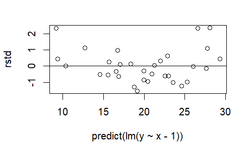

```r
plot(predict(lm(y~x-1)),rstd)
abline(h=0)
```